# Assignment #2: Meta-analysis of Ocean Acidification Effects on Behaviour

(Rick) Zirui Zhang u7457512

20/10/2022

# **Statistical Analysis**

### 1.Install packages

```r
#Use  p_load function in the pacman to install and library a load of packages that we'll use.
library(pacman)
p_load(bookdown, tidyverse, ggforce, flextable, latex2exp, magick, plotrix, readxl, janitor, devtools,dplyr, gridExtra, cowplot, rstatix, GGally, metafor, DIZutils, png, MASS, emmeans, R.rsp,orchaRd, meta)
```

### 2.Import clark data into R, data Wrangling and generate the summary statistics for each of the fish species’ average activity for each treatment.

```r
#import clark data into R
path <- "OA_activitydat_20190302_BIOL3207.csv"
data_c <- read_csv(path)
```

```
## ──────────────────────────────────────────────────────── Delimiter: "," chr
## (5): loc, species, treatment, size, comment dbl (4): ...1, animal_id, sl,
## activity
```

```r
#import metadata data into R
path_m <- "ocean_meta_data.csv"
meta_data <- read_csv(path_m)
#import paperdata into R
path_c <- "clark_paper_data.csv"
paper_data <- read_csv(path_c)
#Observe the structure of the  data
head(meta_data)
```

```
## # A tibble: 6 × 22
##   Study Authors    Year …¹ Year …² Title Journal Pub y…³ 2017 …⁴ Avera…⁵ Effec…⁶
##   <chr> <chr>        <dbl>   <dbl> <chr> <chr>   <chr>   <chr>     <dbl> <chr>
## 1 a1    Munday et…    2009    2009 Ocea… PNAS    9.432   9.504        27 Strong
## 2 a1    Munday et…    2009    2009 Ocea… PNAS    9.432   9.504        27 Strong
## 3 a1    Munday et…    2009    2009 Ocea… PNAS    9.432   9.504        27 Strong
## 4 a1    Munday et…    2009    2009 Ocea… PNAS    9.432   9.504        27 Strong
## 5 a1    Munday et…    2009    2009 Ocea… PNAS    9.432   9.504        27 Strong
## 6 a1    Munday et…    2009    2009 Ocea… PNAS    9.432   9.504        27 Strong
## # … with 12 more variables: Species <chr>, `Climate (FishBase)` <chr>,
## #   `Env cue/stimulus?` <chr>, `Cue/stimulus type` <chr>,
## #   `Behavioural metric` <chr>, `Life stage` <chr>, ctrl.n <dbl>,
## #   ctrl.mean <dbl>, ctrl.sd <dbl>, oa.n <dbl>, oa.mean <dbl>, oa.sd <dbl>, and
## #   abbreviated variable names ¹`Year (online)`, ²`Year (print)`,
## #   ³`Pub year IF`, ⁴`2017 IF`, ⁵`Average n`, ⁶`Effect type`
```

```r
head(paper_data)
```

```
## # A tibble: 1 × 15
##   Study Authors    Year …¹ Year …² Title Journal Pub y…³ 2017 …⁴ Avera…⁵ Effec…⁶
##   <chr> <chr>        <dbl>   <dbl> <chr> <chr>     <dbl>   <dbl>   <dbl> <chr>
## 1 a92   Clark et …    2020    2020 Ocea… Nature     69.5    41.6      45 Weak
## # … with 5 more variables: `Climate (FishBase)` <chr>,
## #   `Env cue/stimulus?` <chr>, `Cue/stimulus type` <lgl>,
## #   `Behavioural metric` <chr>, `Life stage` <chr>, and abbreviated variable
## #   names ¹`Year (online)`, ²`Year (print)`, ³`Pub year IF`, ⁴`2017 IF`,
## #   ⁵`Average n`, ⁶`Effect type`
```

```r
#In comparison, the summary statistics for each of the fish species’ average activity for each treatment in meta_data are in one column, and we need to get the summary statistics data and divide them into different columns like the form of meta_data

#omit all rows with NA values in any column
data_c <- na.omit(data_c)
# Drop irrelevant columns
new_data_c <- subset(data_c, select = -c(comment, loc))
# Check spelling in species and treatment
unique(new_data_c$species)
```

```
## [1] "ambon"     "lemon"     "chromis"   "acantho"   "humbug"    "whitedams"
```

```r
unique(new_data_c$treatment)
```

```
## [1] "CO2"     "control"
```

```r
#seems no spelling error
#Generate a summary table of statistics (means, SD, N) for each of the fish species’ average activity for each treatment and divide them into different columns like the form of meta_data
mat <-   summarise_at(group_by(new_data_c,species,treatment),vars(activity),funs(mean(.,),sd(.,))) %>%
  pivot_wider(names_from = treatment, values_from = c(mean,sd))
id <- summarise_at(group_by(new_data_c,species,treatment),vars(animal_id),funs(length(unique(.,)))) %>%
  pivot_wider(names_from = treatment, values_from = c(animal_id))
#Combining these two sets of data together
data_2 <- merge(mat,id)
#Modify the column name of data_3 to make it the same as in the metadata
colnames(data_2) <- c("Species", "oa.mean","ctrl.mean","oa.sd","ctrl.sd","oa.n","ctrl.n")
data_2
```

```
##     Species  oa.mean ctrl.mean     oa.sd   ctrl.sd oa.n ctrl.n
## 1   acantho 27.30042  28.92639 10.415559 11.246347   86     90
## 2     ambon 18.39429  17.34102 12.200326 11.451588   22     21
## 3   chromis 24.78010  26.09986 10.975005  9.125352   14     20
## 4    humbug 40.28306  34.91652 11.915992 13.867278   52     59
## 5     lemon 26.04157  19.79766 10.957164 12.256353   19     30
## 6 whitedams 24.45733  26.58624  9.950437 10.936592   60     61
```

### 2.Merge the summary statistics generated from 1) with the metadata.

```r
data_3 <- cbind(paper_data,data_2)
data_3
```

```
##   Study     Authors Year (online) Year (print)
## 1   a92 Clark et al          2020         2020
## 2   a92 Clark et al          2020         2020
## 3   a92 Clark et al          2020         2020
## 4   a92 Clark et al          2020         2020
## 5   a92 Clark et al          2020         2020
## 6   a92 Clark et al          2020         2020
##                                                                    Title
## 1 Ocean acidification does not impair the behaviour of coral reef fishes
## 2 Ocean acidification does not impair the behaviour of coral reef fishes
## 3 Ocean acidification does not impair the behaviour of coral reef fishes
## 4 Ocean acidification does not impair the behaviour of coral reef fishes
## 5 Ocean acidification does not impair the behaviour of coral reef fishes
## 6 Ocean acidification does not impair the behaviour of coral reef fishes
##   Journal Pub year IF 2017 IF Average n Effect type Climate (FishBase)
```

[output cut: 20 more lines]

### 3.Merge the combined summary statistics and metadata into the larger meta-analysis dataset

```r
# use rbind to combine
data_f <- rbind(data_3,meta_data)
```

### 4.Correctly calculate the log response ratio (lnRR) effect size for every row of the dataframe using metafor’s escalc() function.

```r
#Calculate Log Response Ratio. where m1i and m2i are the observed means of the two groups, sd1i and sd2i are the observed standard deviations, and n1i and n2i denote the number of individuals in each group. Use the var.names argument to rename the effect size and sampling variance to “lnRR” and “V_lnRR”.
rom_data <- metafor::escalc(measure = "ROM", m1i = oa.mean, m2i = ctrl.mean, sd1i = oa.sd, sd2i = ctrl.sd, n1i = oa.n, n2i = ctrl.n, data = data_f,
    var.names = c("lnRR", "V_lnRR"))
##remove NAs
rom_data<-na.omit(rom_data)
```

### 5.Correct meta-analytic model fitted to the data that controls for the sampling variance of lnRR. The model should include a random effect of study and observation. Use metafor’s rma.mv() function.

```r
# Add observation level variable to rom_data.
rom_data <- rom_data %>% mutate(residual = 1:n())
# Meta-analytic model include a random effect of study and observation.
MLMA <- metafor::rma.mv(lnRR ~ 1, V = V_lnRR, random = list( ~1| Study, ~1 | residual), data=rom_data)
MLMA
```

```
##
## Multivariate Meta-Analysis Model (k = 795; method: REML)
##
## Variance Components:
##
##             estim    sqrt  nlvls  fixed    factor
## sigma^2.1  0.4792  0.6922     91     no     Study
## sigma^2.2  4.0497  2.0124    795     no  residual
##
## Test for Heterogeneity:
## Q(df = 794) = 736088678.9542, p-val < .0001
##
## Model Results:
##
## estimate      se    zval    pval    ci.lb   ci.ub
##   0.1273  0.1140  1.1162  0.2643  -0.0962  0.3508
##
## ---
## Signif. codes:  0 '***' 0.001 '**' 0.01 '*' 0.05 '.' 0.1 ' ' 1
```

### 6.Findings and interpretation of the above results

#### Correct presentation and interpretation of overall meta-analytic mean and measures of uncertainty around the mean estimate (e.g., 95% confidence intervals).

##### Overall meta-analytic mean

```r
#We can see the overall meta-analytic mean from the model by extracting the intercept.
coef(MLMA)
```

```
##  intrcpt
## 0.127299
```

It is estimated to be 0.127299, which tells us that the mean lnRR value is positive, but there is a rather weak overall association between ocean acidification and fish behavior change when we pool across all studies.

##### Measures of uncertainty around the mean estimate (95% confidence intervals).

```r
str(MLMA$ci.lb)
```

```
##  num -0.0962
```

```r
str(MLMA$ci.ub)
```

```
##  num 0.351
```

We can extract the 95% confidence intervals which range from -0.0962331 to 0.3508311. 95% of the time we would expect the true mean to fall between lnRR values of `-0.0962331 to 0.3508311.And if we were to repeat the experiment many times, 95% of the confidence intervals constructed would contain the true meta-analytic mean.

##### Measures of heterogeneity in effect size estimates across studies

```r
# Calculate I2
i2_vals <- orchaRd::i2_ml(MLMA)

i2 <- tibble(type = firstup(gsub("I2_", "",names(i2_vals))), I2 = i2_vals)
flextable(i2) %>%
    align(part = "header", align = "center") %>%
    compose(part = "header", j = 1, value = as_paragraph(as_b("Type"))) %>%
    compose(part = "header", j = 2, value = as_paragraph(as_b("I"), as_b(as_sup("2")),
        as_b("(%)")))
```

Table 1: Total effect size hetereogneity, as well as the proportion of hetereogeneity in effects resulting from Study and Observational

| Type | I2(%) |
| --- | --- |
| Total | 100.00000 |
| Study | 10.58073 |
| Residual | 89.41927 |

```r
# Calculate the prediction intervals
pis <- predict(MLMA)
pis
```

```
##
##    pred     se   ci.lb  ci.ub   pi.lb  pi.ub
##  0.1273 0.1140 -0.0962 0.3508 -4.0497 4.3043
```

Overall, from table.1 the $I_{Total}^2$ is 99.9999999.Because sampling variation barely affect the total variation in effects, which means we have highly heterogeneous effect size data. From the multilevel meta-analytic model we found that only 10.5807302 of the total variation in effect size estimates was due to between-study variation.

Our 95% prediction intervals are wide. Effect sizes (lnRR) are expected to range from -4.049719 to 4.3043171 95% of the time with repeated experiments, suggesting a lot of inconsistency between studies.

We can also see that the null hypothesis that lnRR = 0 can not be rejected, which we can see from the p-value being > 0.05.

##### Forest plot showing the mean estimate, 95% confidence interval, and prediction interval

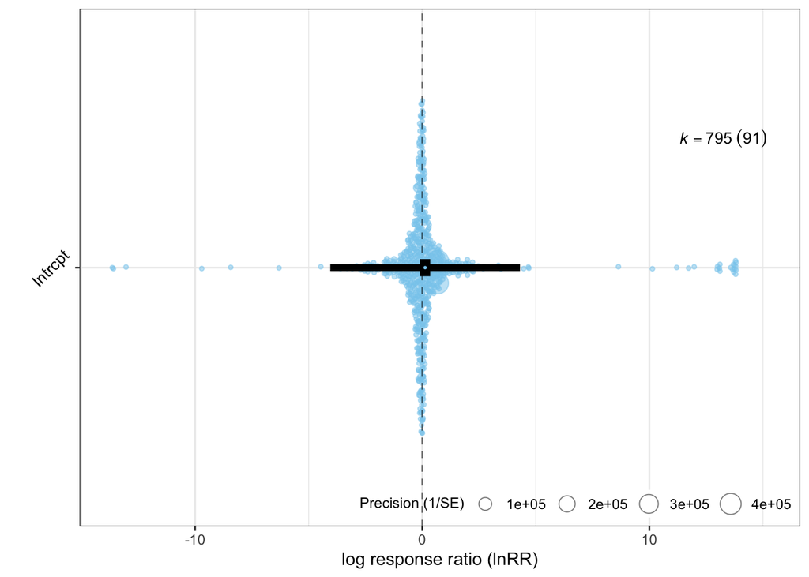

Figure 1: Orchard plot showing the mean estimate, 95% confidence interval, and prediction interval, k = the number of effect sizes and the number of studies are in brackets. The hollow dots in the middle represent mean estimate，bold lines represent 95% confidence interval, thin lines represent prediction interval, The blue circles represent individual effect sizes

```r
#use orchard plots (Improved forest plot) to show the mean estimate, 95% confidence interval, and prediction interval

orchaRd::orchard_plot(MLMA, mod = "1",  group = "Study" , data = rom_data,
    xlab = "log response ratio (lnRR)", trunk.size= 0.5, branch.size = 5, twig.size = 2, angle = 45)
```

### 7.Funnel plot for visually assessing the possibility of publication bias.

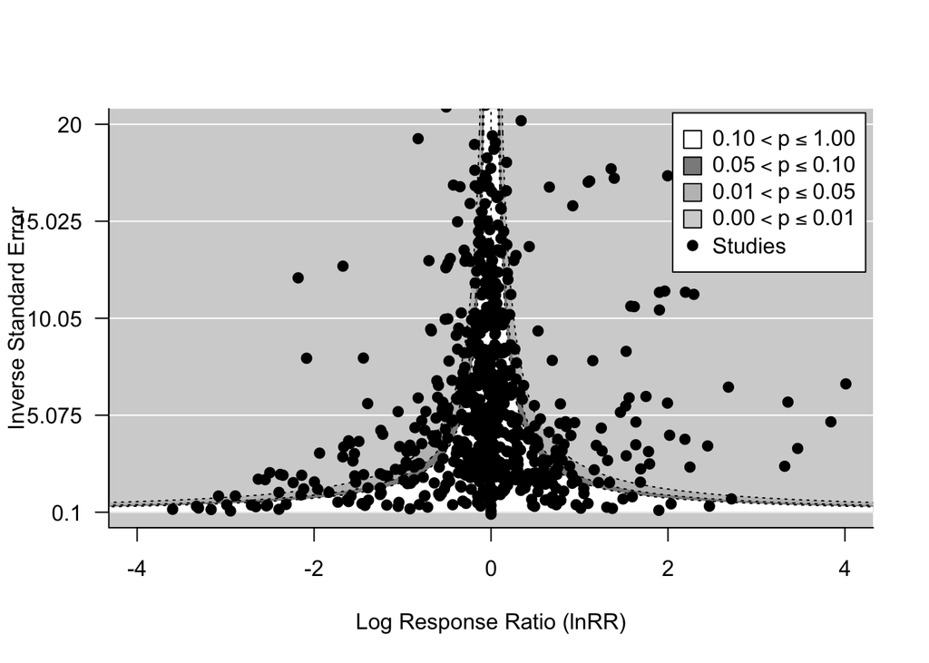

Figure 2: Funnel plot depicting elevated CO2 relative to some control on fish behaviour as a function of precision (1 / SE). The dotted lines are the theoretical 95% sampling variance intervals - the interval with which we expect effect size estimates to fall within if only sampling variance drives differences in effects. Shaded regions represent the p-value of studies. The white region indicates studies where the p-value is between 0.1 and 1; dark gray where the p-value of studies is between 0.05 and 0.1 and the lighter gray regions where the p-value of studies is significant.

```r
#Make a funnel plot to visualize the data in relation to the precision, inverse sampling standard error.
metafor::funnel(x = rom_data$lnRR, vi= rom_data$V_lnRR, yaxis = "seinv", xlab = "Log Response Ratio (lnRR)",level = c(0.1,0.05,0.01) ,shade = c("white", "gray55", "gray 75"),
    las = 1, ylim = c(0.1, 20), xlim = c(-4, 4),  legend = TRUE)
```

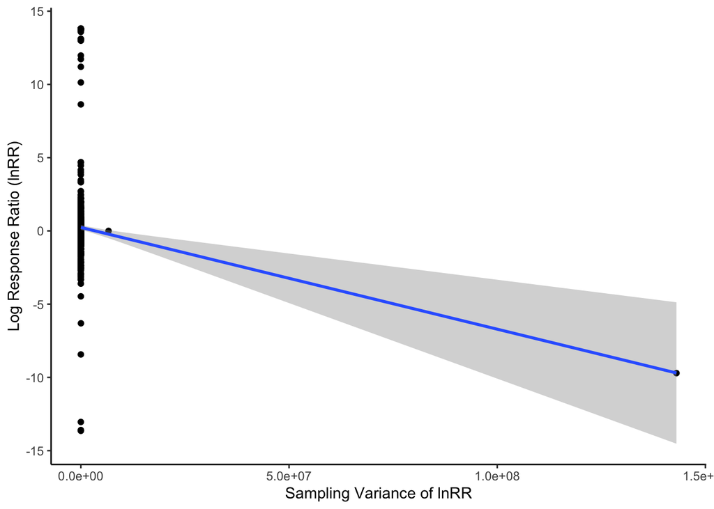

Figure 3: Plot of lnRR against sampling variance for lnRR. A linear model was fit to the data.

```r
#Fitting a Multilevel Meta-Regression model to Test and Correct for Publication bias
ggplot(rom_data, aes(y = lnRR, x= V_lnRR,)) + geom_point() + geom_smooth(method = lm) + labs(y = "Log Response Ratio (lnRR)", x = "Sampling Variance of lnRR") +
    theme_classic()
```

If we do not filter the sampling Variance of lnRR, we find two extremely large value of variance that significantly pulls down the slope, and prevented us from analyzing the distribution of the sample.

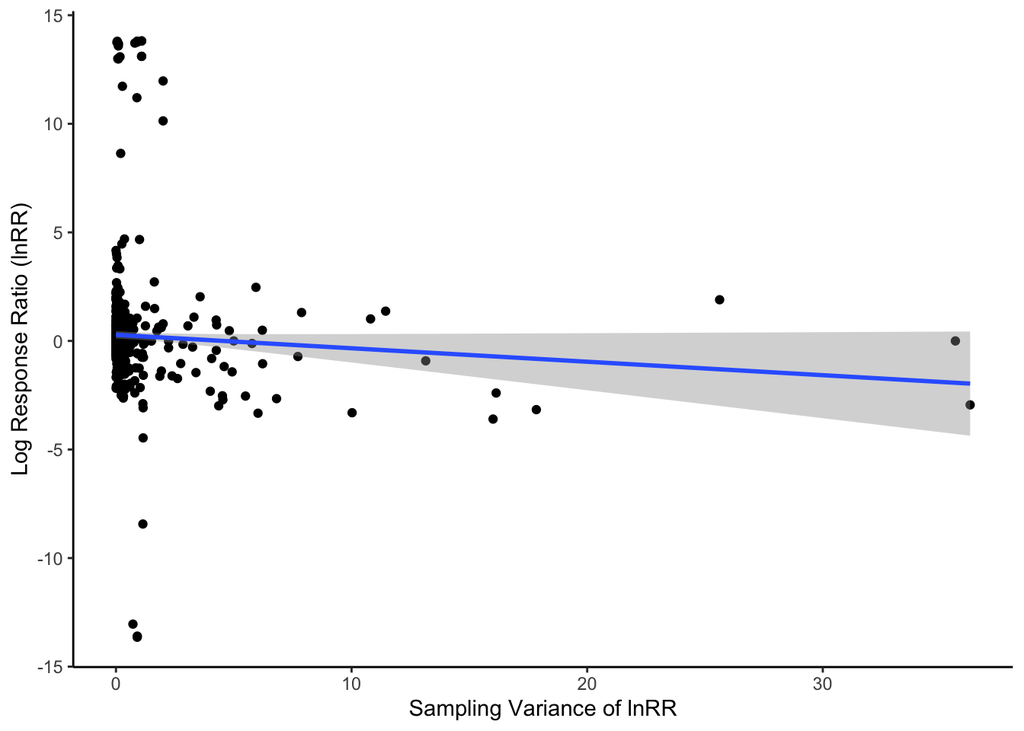

Figure 4: Plot of lnRR against sampling variance for lnRR. A linear model was fit to the data.(X-axis is filtered)

```r
# filter the sampling Variance of lnRR，
po_rom_data <- rom_data %>% filter(V_lnRR < 1.0e+04)
ggplot(po_rom_data, aes(y = lnRR, x= V_lnRR,)) + geom_point() + geom_smooth(method = lm) + labs(y = "Log Response Ratio (lnRR)", x = "Sampling Variance of lnRR") +
    theme_classic()
```

### 8.Time-lag plot assessing how effect sizes may or may not have changed through time.

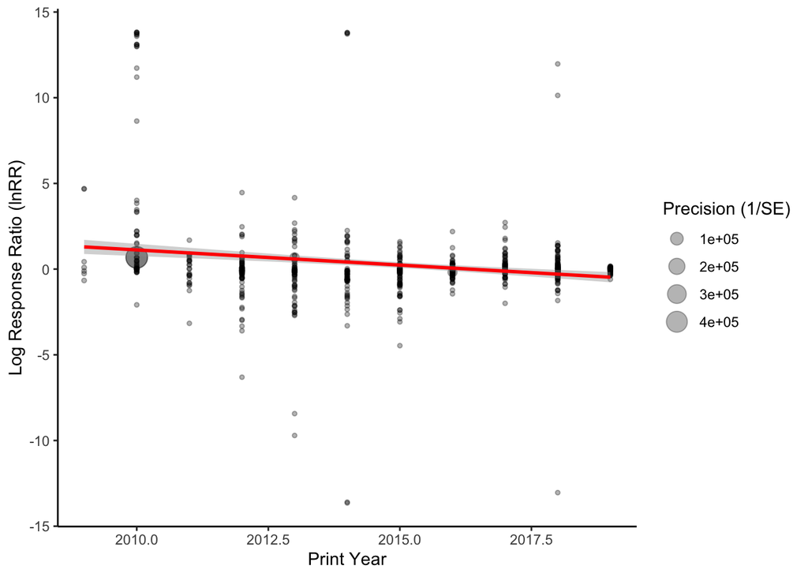

Figure 5: Plot of lnRR as a function of Print year. Points are scaled in relation to their precision (1/sqrt(V_lnRR)). Small points indicate effects with low precision or high sampling varaince

```r
ggplot(rom_data, aes(y = lnRR, x = Year..print., size = 1/sqrt(V_lnRR))) + geom_point(alpha = 0.3) +
    geom_smooth(method = lm, col = "red", show.legend = FALSE) + labs(x = "Print Year",
    y = "Log Response Ratio (lnRR)", size = "Precision (1/SE)") +
    theme_classic()
```

In this plot, we can see that there does seem to be a clear negative correlation between lnRR and year, but because there are several lnRR values that are too small , which produce the big point.To see the variation between precision, we filter these values out

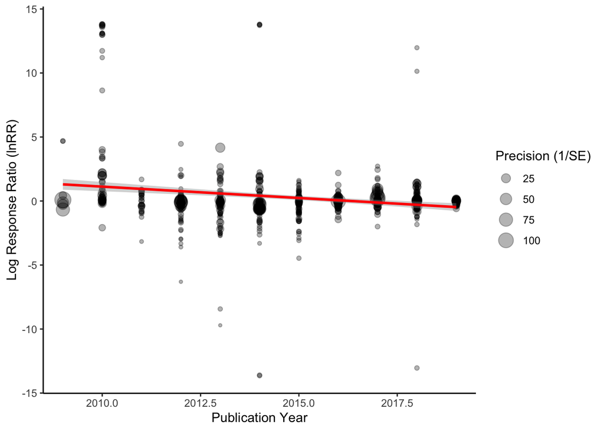

Figure 6: Plot of lnRR as a function of Print year and filter out the too-small V_lnRR,. Points are scaled in relation to their precision (1/sqrt(V_lnRR)). Small points indicate effects with low precision or high sampling varaince

```r
Tl_rom_data <- rom_data %>% filter(V_lnRR > 1.0e-05)
ggplot(Tl_rom_data, aes(y = lnRR, x = Year..print., size = sqrt(1/V_lnRR))) + geom_point(alpha = 0.3) +
    geom_smooth(method = lm, col = "red", show.legend = FALSE) + labs(x = "Publication Year",
    y = "Log Response Ratio (lnRR)", size = "Precision (1/SE)") +
    theme_classic()
```

### 9.Formal meta-regression model that includes year as a moderator (fixed effect) to test for time-lag bias

```r
# Including year as moderator
MLMY <- metafor::rma.mv(lnRR ~ Year..print., V = V_lnRR, random = list( ~1| Study, ~1 | residual), data=rom_data)
MLMY
```

```
##
## Multivariate Meta-Analysis Model (k = 795; method: REML)
##
## Variance Components:
##
##             estim    sqrt  nlvls  fixed    factor
## sigma^2.1  0.3961  0.6294     91     no     Study
## sigma^2.2  4.0495  2.0123    795     no  residual
##
## Test for Residual Heterogeneity:
## QE(df = 793) = 161793949.9270, p-val < .0001
##
## Test of Moderators (coefficient 2):
## QM(df = 1) = 8.1284, p-val = 0.0044
##
## Model Results:
##
##               estimate       se     zval    pval    ci.lb     ci.ub
## intrcpt       245.3194  85.9992   2.8526  0.0043  76.7641  413.8746  **
## Year..print.   -0.1217   0.0427  -2.8510  0.0044  -0.2053   -0.0380  **
##
## ---
## Signif. codes:  0 '***' 0.001 '**' 0.01 '*' 0.05 '.' 0.1 ' ' 1
```

```r
r2_time <- orchaRd::r2_ml(MLMY)
r2_time
```

```
##    R2_marginal R2_conditional
##     0.02427226     0.11121779
```

```r
MLMI <- metafor::rma.mv(lnRR ~ (1/V_lnRR), V = V_lnRR, random = list( ~1| Study, ~1 | residual), data=rom_data)
MLMI
```

```
##
## Multivariate Meta-Analysis Model (k = 795; method: REML)
##
## Variance Components:
##
##             estim    sqrt  nlvls  fixed    factor
## sigma^2.1  0.4792  0.6922     91     no     Study
## sigma^2.2  4.0497  2.0124    795     no  residual
##
## Test for Heterogeneity:
## Q(df = 794) = 736088678.9542, p-val < .0001
##
## Model Results:
##
## estimate      se    zval    pval    ci.lb   ci.ub
##   0.1273  0.1140  1.1162  0.2643  -0.0962  0.3508
##
## ---
## Signif. codes:  0 '***' 0.001 '**' 0.01 '*' 0.05 '.' 0.1 ' ' 1
```

```r
r2_A <- orchaRd::r2_ml(MLMI)
r2_A
```

```
##    R2_marginal R2_conditional
##      0.0000000      0.1058073
```

### 11.A paragraph that discusses the potential for publication bias based on the meta-regression results.

Based on the above two points, we can get Publication bias is reflected here because there are few effects in the opposite direction, and when the sample size is small, our hypothesis does not predict that direction, so the sampling variance is large. It shows these studies are difficult to publish, or that the authors are unlikely to believe them and therefore do not publish them.

We can see from Fig. 6 The impact of ocean acidification studies on fish behaviour has declined. In this plot, we can see that there does seem to be a clear negative correlation between lnRR and year. Effect size magnitudes (lnRR) in this area have been declining over the past decade, with a large number of effect size magnitudes >5 in 2010-2014 and mostly <3 after 2015. average effect size magnitudes in early studies were too large, hovering at moderate effect sizes from 2012 to 2014 and almost disappeared in recent years.These early studies appear to have a far higher effect size compared with studies that are done in later years.In the early studies, the large effects of the great effect of acidification on fish behavior have not appeared in most of the past five years.

Based on the above points, we can get Two other publication bias maybe reflected here. First, Methodological biases. Experiments with small sample sizes are more prone to statistical error, and studies with large sample sizes should be more trustworthy than those with small sample sizes, but in the data used for this assignment, almost all studies with maximum effect sizes had relatively low average sample sizes (below 30 fish). Second, Publication and citation bias. At the beginning of this field, the results of showing strong effects are often easier to publish than research that displayed weaker or invalid results, and published on magazines that have a greater impact. The author and journal articles with optional publications may help the spread of the research and continuous existence of the strong effect of this field. Even if these effects may not be true due to low samples or other reasons.

Time-lag explains 0.0242723 of the variation in lnRR. Since it is small, it is reflected we just have little evidence of a time-lag bias.

### 12.Identify any studies contributing to publication bias. How do your updated meta-analysis results compare with a meta-analysis by Clement et. al. (2022)? Are there any concerns about these studies? If so, describe using references to existing papers what concerns have been raised?

#### Identify studies contributing to publication bias.

We can see from Fig. 6. A large number of studies prior to 2012 had effect sizes >5, and after 2015 were mostly <3. The average effect size was too large for earlier studies, which appeared to have higher effect sizes than studies done later. The large effects of ocean acidification on fish behavior in earlier studies were absent for most studies of the past five years. Therefore, it is possible that these previous studies have caused publication bias, and we will delete the data before 2012.

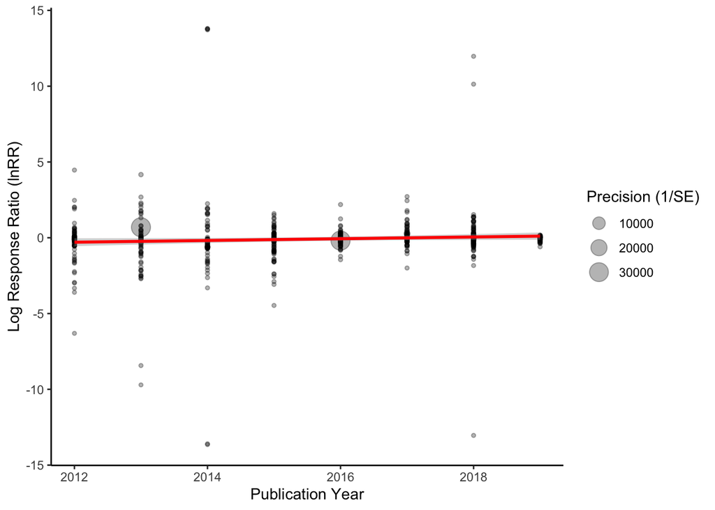

```r
IS_rom_data <- rom_data %>% filter( Year..print.> 2011)
ggplot(IS_rom_data, aes(y = lnRR, x = Year..print., size = sqrt(1/V_lnRR))) + geom_point(alpha = 0.3) +
    geom_smooth(method = lm, col = "red", show.legend = FALSE) + labs(x = "Publication Year",
    y = "Log Response Ratio (lnRR)", size = "Precision (1/SE)") +
    theme_classic()
```

We can see from Fig. 7. After removing studies before 2012, the decline effect from 2012 to 2019 is no longer significant, from which we can conclude that studies with higher effect size before 2012 may have contributed to some of the publication bias.

We can see from Fig. 3. If we do not filter the sampling Variance of lnRR, we find two extremely large value of variance that significantly pulls down the slope, which has a great impact to the slope and distribution of effect sizes.We can conclude that studies with extremely large value of variance may have contributed to some of the publication bias.

#### My meta-analysis results compare with a meta-analysis by Clement et. al. (2022)

From the results point of view, the results of these two meta-analysis are roughly the same. All detected the strong decline effect, also proposed several possibilities: Early studies have small samples and selective publishing bias.

Apart from that, They looked at the impact of variables such as average citations, total citations since 2020 and journal impact factor on the data. More strongly proved Publication and citation bias. Results showing strong effects were generally more likely to be published in higher impact journals than studies showing weak or invalid results. They found that the most prominent effects of ocean acidification on fish behavior were published in journals with high impact factors. In addition, these studies all had high citation frequencies, indicating a stronger impact on the field than others.

However, the biggest difference between the two analyses is that meta-analysis by Clement et. al. (2022)’s effect sizes were transformed to the absolute value of lnRR. Such a conversion provides only a measure of effect size. Thus, absolute effect sizes would be overestimated, but could still be used to test for a decreasing effect of effect size magnitude over time. Note, however, that by ignoring directional effect sizes, I think this makes it difficult to make true population-level inferences.

#### Concerns about these studies

The results suggest that the large effects of ocean acidification on fish behaviour that emerged in earlier studies have been mostly absent in the last five years. Since the birth of the field, studies of ocean acidification on fish behavior have been characterized by declining effects.

The bad news is that the vast majority of early studies with large effects in this field were characterized by low sample sizes, but were published in high-impact journals that have had a significant impact on the field in terms of citation rates and have even influenced the course of research in this area of science. Indeed, a recent analysis suggests that there is a publication bias in field studies of the biology of global change, which contributes to the proliferation of underpowered studies that report excessive effect sizes [1].

The good news is that the impact of the earlier studies is declining year by year and the effect size of the field is levelling off. But it also requires us to reflect on Whether this decline effect is common in the field of ecology and even the entire biology (Similar results are also reported in other areas of ecology and evolution. Maybe the most noteworthy research on land plants to react to high carbon dioxide) [2], as well as its impact on our scientific development process. Whether we can then improve the methodology in future studies to minimize the possibility of declining effects.

# **Reproducibility**

### Github

[My GitHub Repository](https://github.com/Like224/Assgnment_2)

### Reference

1. Yang Y, Hillebrand H, Malgorzata L, Cleasby I, Nakagawa S. Low statistical power and overestimated anthropogenic impacts, exacerbated by publication bias, dominate field studies in global change biol- ogy. EcoEvoRxiv. 2021.
2. Murtaugh PA. Journal quality, effect size, and publication bias in meta-analysis. Ecology. 2002; 83:1162–6.